# Analyzing Borrower Data From the Propser Loan Dataset.

Focusing on a subset of the data including customers who are students, are we able to find statistical differences in their data and behavior?

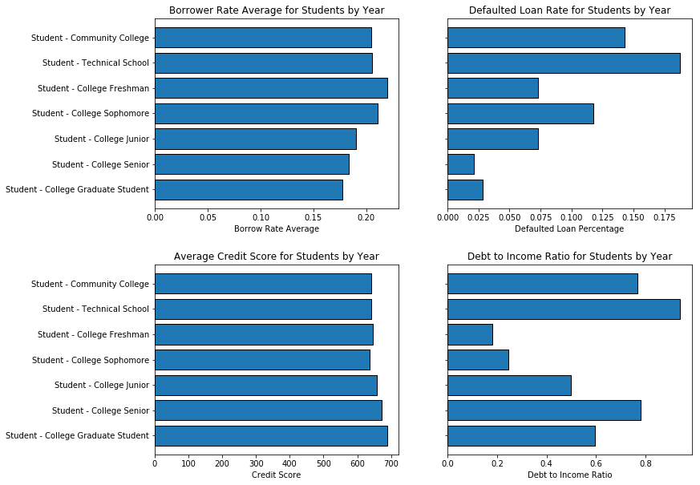

```python
f, ax = plt.subplots(2, 2, sharey = True, figsize = (12., 10))
plt.subplots_adjust(hspace=0.3)
averages_list = [borrow_rate_avg[::-1], default_rate_avg[::-1], credit_score_avg[::-1],debt_to_income_avg[::-1]]
titles = ['Borrower Rate Average for Students by Year','Defaulted Loan Rate for Students by Year',
          'Average Credit Score for Students by Year','Debt to Income Ratio for Students by Year']
labels = ['Borrow Rate Average', 'Defaulted Loan Percentage', 'Credit Score', 'Debt to Income Ratio']
idx = 0

for x in range(2):
    for y in range(2):
        ax[x,y].barh(student_df.Occupation.unique().categories[::-1], averages_list[idx], edgecolor = 'black')
        ax[x,y].set_title(f"{titles[idx]}")
        ax[x,y].set_xlabel(f"{labels[idx]}")
        idx += 1
```

We find that students who attend a technical school have the greatest defaulted loan rate at around 18%. It also appears that borrower rates decrease as students progress through their education. At the same time debt to income ratio appears to increase starting around 18% for freshman and up to around 80% once they are seniors.

**Are the differences observed between freshman and seniors statistically significant?**

```
P-Value =  0.1359
```

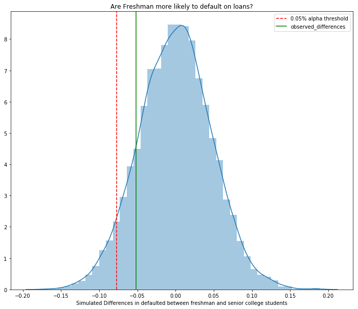

```python
hypothesis_testing(student_df, 'defaulted',"Occupation", freshman, senior, 40, 5, ">=", "Are Freshman more likely to default on loans?")
```

Given our p-value of 0.13 we fail to reject the null hypothesis that freshman are more likely to default than seniors.

```
P-Value =  0.0291
```

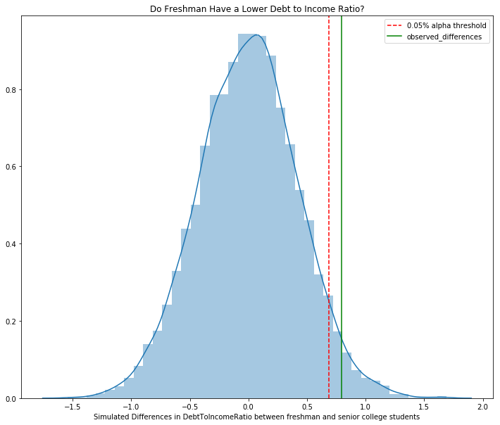

```python
hypothesis_testing(student_df, 'DebtToIncomeRatio',"Occupation", freshman, senior, 40, 5, "<=", "Do Freshman Have a Lower Debt to Income Ratio?")
```

Given the p-value of 0.03 we reject our null hypothesis that freshman have a lower debt to income ratio.

```
P-Value =  0.0248
```

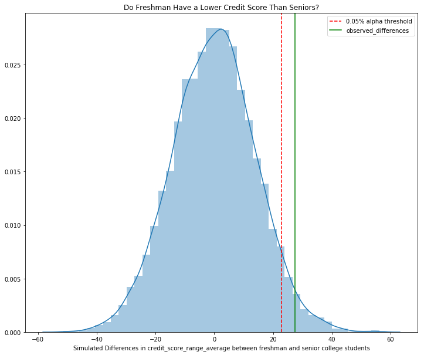

```python
hypothesis_testing(student_df, 'credit_score_range_average',"Occupation", freshman, senior, 40, 5, "<=", "Do Freshman Have a Lower Credit Score Than Seniors?")
```

Given our p-value of 0.02 we reject our null hypothesis that freshman have worse credit scores than senior students.

```
P-Value =  0.03
```

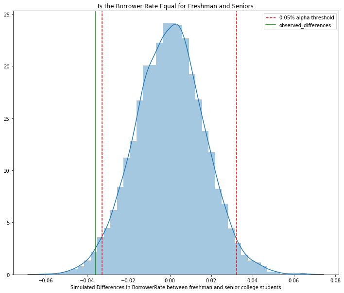

```python
hypothesis_testing(student_df, 'BorrowerRate',"Occupation", freshman, senior, 40, 5, "=", "Is the Borrower Rate Equal for Freshman and Seniors")
```

Given our p-value of 0.03 we reject our null hypothesis that the borrower rate is equal for both freshman and seniors

Given our findings, it appears that certain features help us determine unique characteristics of certain groups of customers which would allow us to classify them into certain groups of potential risk, potential gains or possibly even identify age based on financial habits.

# Can we determine which customers will result in a defaulted or charged off loan?

First we'll take a quick glance at the differences in gains and losses between defaulted/charged off loans and money earned from completed loans in order to determine which is more valuable to the company.

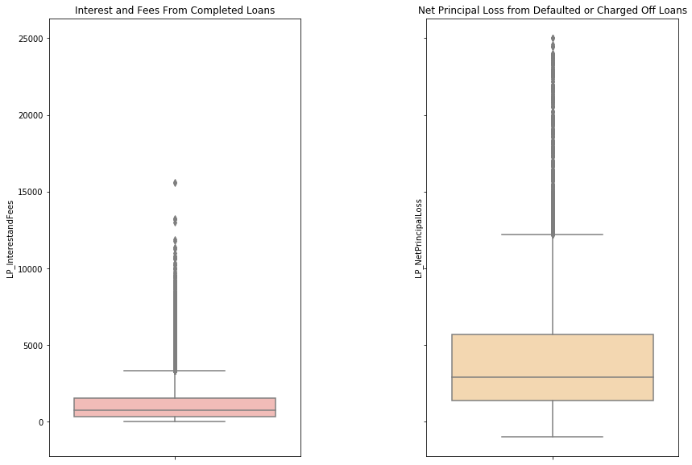

```python
f, ax = plt.subplots(1,2, figsize = (14, 10), sharey = True)
plt.subplots_adjust(wspace=0.5)
sns.boxplot(completed_gain, orient = 'vertical', ax = ax[0], palette = 'Pastel1');
sns.boxplot(default_loss, orient = 'vertical', ax = ax[1], palette = "Pastel1_r");
ax[0].set_title("Interest and Fees From Completed Loans");
ax[1].set_title("Net Principal Loss from Defaulted or Charged Off Loans");
```

It is evident that on average losses from defaulted/charged off loans far out weigh the gains from interest and fees on completed loans. It would benefit the company if one could determine which customers will default even at the risk of potentially denying customers that will not.

What variables play the most important role in determining if a borrower will default or not?

In order to determine this we will utilize sklearns decision tree classifier which will return a ranking of feature importances representing the proportion out of 100% each feature contributes to the models decision.

```
Text(0.5,0,'Contribution')
```

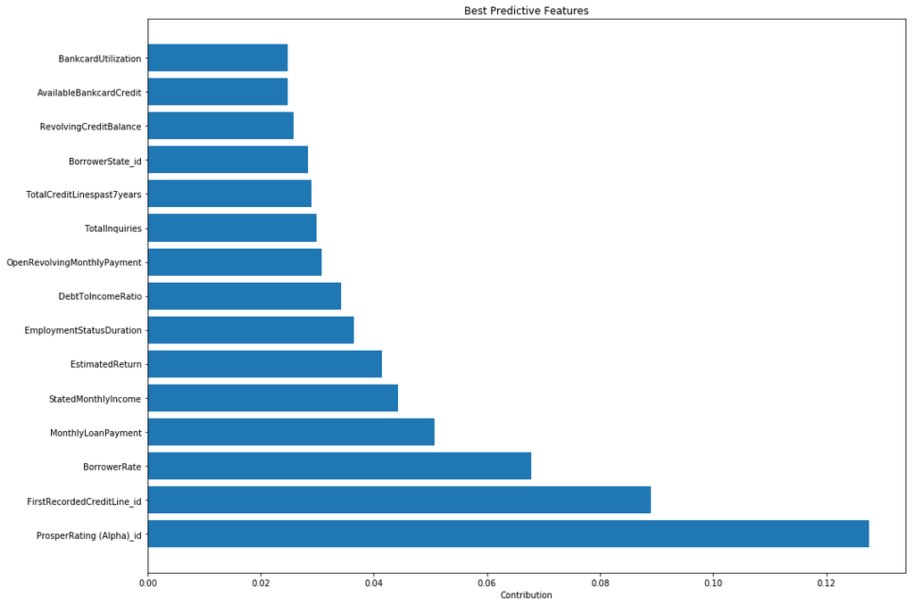

```python
plt.figure(figsize = (16, 12))
plt.barh(best_feats[:16], sorted(tree.feature_importances_)[:len(tree.feature_importances_)-16:-1])
plt.title("Best Predictive Features")
plt.xlabel("Contribution")
```

**1. Visualize PropserRating and Default counts**

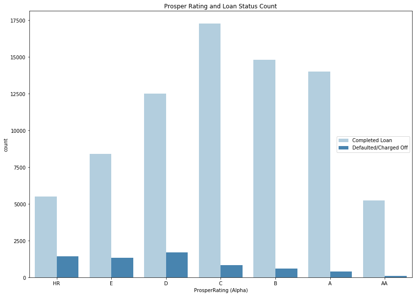

```python
plt.figure(figsize = (14, 10))
sns.countplot(df['ProsperRating (Alpha)'], hue = df['defaults'], palette = 'Blues', order = ['HR', 'E', 'D', 'C', 'B', 'A', 'AA']);
plt.title("Prosper Rating and Loan Status Count")
plt.legend(["Completed Loan", "Defaulted/Charged Off"], loc = 'center right')
```

We can see that the completed loans take on a near gaussian distribution with the majority being in the C rating. Meanwhile as the Prosper Rating gets higher on the scale, the amount of defaulted or charged off loans show a downward trend with the least amount at the highest (AA) rating.

**2. Borrower Rate for Customers That Completed Their Loans vs Customers That Defaulted**

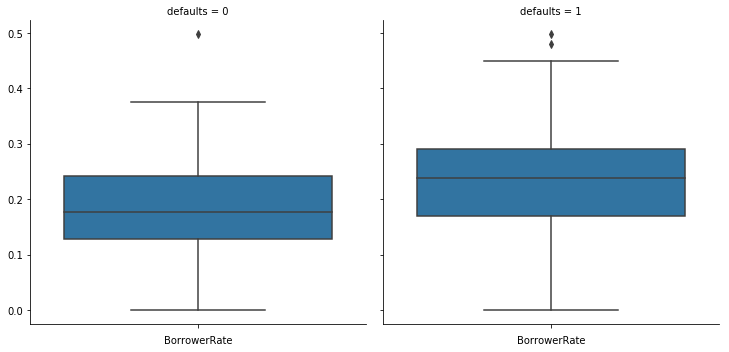

```python
create_facet(df, 'defaults', 'BorrowerRate', sns.boxplot, order = 'defaults')
```

We can see that there is a higher mean borrower rate for the defaulted or charged off loans at rough 25% while the borrower rate for completed loans has a mean of roughly 18%. Also, the 3rd quartile boundary is roughly 5% higher for defaulted loans.

**3. Monthly Payments of Customers Who Defaulted vs Customers Who Default.**

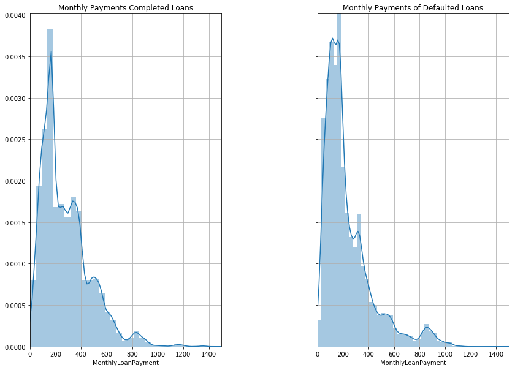

```python
f , ax = plt.subplots(1, 2, sharey = True, sharex = True, figsize = (14, 10))
plt.subplots_adjust(wspace = 0.5);
sns.distplot(df.query("defaults == 0")['MonthlyLoanPayment'], ax = ax[0], label = 'Completed Loans');
sns.distplot(df.query("defaults == 1")['MonthlyLoanPayment'], ax = ax[1], label = 'Defaulted/Charged off Loans');
ax[0].set_xlim(0, 1500);
ax[0].grid();
ax[1].grid();
ax[0].set_title("Monthly Payments Completed Loans");
ax[1].set_title("Monthly Payments of Defaulted Loans");
```

Now that we have taken a look at some of the top features for prediction we will assign these to our train and test set variables and attempt to run the Decision Tree again.

```python
train_preds = tree.predict(x_train)
print("Training set accuracy = ", accuracy_score(train_preds, y_train))
test_preds = tree.predict(x_test)
print("Test set accuracy = ", accuracy_score(test_preds, y_test))
```

```
Training set accuracy =  1.0
Test set accuracy =  0.8208261389294728
```

$Precision \space Score:\frac{TP} {(TP + FP)}$

The precision is the ratio tp / (tp + fp) where tp is the number of true positives and fp the number of false positives. The precision is intuitively the ability of the classifier not to label as positive a sample that is negative.

The best value is 1 and the worst value is 0.

https://scikit-learn.org/stable/modules/generated/sklearn.metrics.precision_score.html

$Recall \space Score: \frac{TP} {(TP + FN)}$

The recall is the ratio tp / (tp + fn) where tp is the number of true positives and fn the number of false negatives. The recall is intuitively the ability of the classifier to find all the positive samples.

The best value is 1 and the worst value is 0.

https://scikit-learn.org/stable/modules/generated/sklearn.metrics.recall_score.html

Confusion Matrix is a representation of our True Negative (Upper Left), False Positive (Upper Right), True Positive (Bottom Right) and False Negative (Bottom Left)

```python
confusion_matrix(y_test, test_preds)
```

```
array([[17041,  2041],
       [ 2006,  1499]], dtype=int64)
```

```python
precision_score(y_test, test_preds)
```

```
0.42344632768361584
```

```python
recall_score(y_test, test_preds)
```

```
0.4276747503566334
```

As we now see our decision tree is doing much worse than the original 80% as calculated by our accuracy_score. It is only able to correctly predict a customer will default 42.5% of the time. Let's now expirement with other models and see if we can improve this score. To do so, we will utilize cross validation testing multiple models.

Create function that will iterate over the selected models and run cross validation on each. After which will print out the resulting scores, mean and standard deviation. In the case of the Support Vector Machine we will first normalize the features with Standard Scaler which centers the mean and tranforms them into a range between [-1, 1]

```
Decision Tree Scores: [0.42026826 0.4295302  0.45190157 0.41983594 0.41387025 0.4295302
 0.45786726 0.42878449 0.42207308 0.41610738]
Decision Tree Mean: 0.4289768629189908
Decision Tree Standard Deviation: 0.014006207460934304
Random Forest Classifier Scores: [0.29806259 0.29753915 0.31543624 0.30574198 0.28337062 0.29679344
 0.31170768 0.30201342 0.30126771 0.30723341]
Random Forest Classifier Mean: 0.301916624713412
Random Forest Classifier Standard Deviation: 0.008521702027995801
Bagging Scores: [0.30923994 0.31618195 0.33631618 0.31469053 0.32214765 0.30797912
 0.35272185 0.32065623 0.31394482 0.32363908]
Bagging Mean: 0.32175173453091815
Bagging Standard Deviation: 0.012900585326813107
Support Vector Machine Scores: [0.14456036 0.17524236 0.16480239 0.15212528 0.14019389 0.14541387
 0.14317673 0.15809098 0.14988814 0.1715138 ]
Support Vector Machine Mean: 0.15450077849681768
Support Vector Machine Standard Deviation: 0.011746884308619261
```

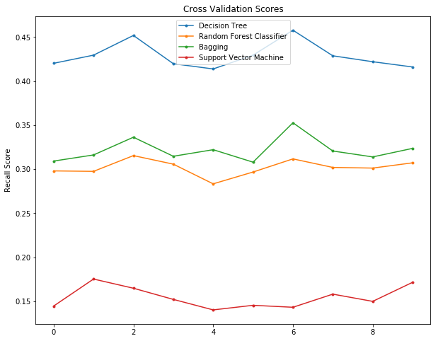

```python
cross_val(models, x_train, y_train)
```

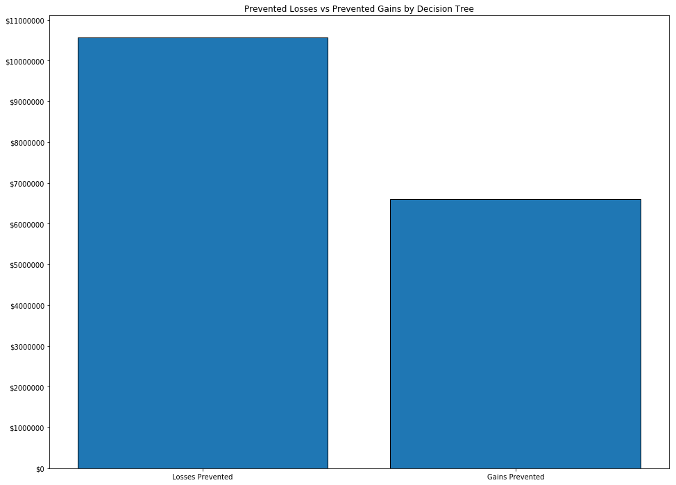

```python
ticks = [i for i in range(0, 12000000, 1000000)]
plt.figure(figsize = (16, 12))
plt.bar(["Losses Prevented", "Gains Prevented"], [estimated_loss_prevention, estimated_gains_lost], edgecolor = 'black');
plt.yticks(ticks, ['$' + str(i)  for i in ticks]);
plt.title("Prevented Losses vs Prevented Gains by Decision Tree");
```